# Used Car Project / Yeoman Yoon

## Defining Problem:

Unlike new cars, used cars have very unique features on top of its brand and models. It is well known that mileage, year, and brand effects the used car a lot. Yet, it is not as easy to predict how people perceive some cars to be more reliant used car. New cars' pricing may determine people's affordability. Or, any other factors can contribute.

Only if we could determine how market price of used cars will be, not only can we sell used cars at more beneficial price, but we can also control purchasing the used car at more reasonable price as dealershop. Find out the market price of used cars in India!

## Import necessary libraries for analysis:

```python
import pandas as pd
import numpy as np
import seaborn as sns
import matplotlib.pyplot as plt
%matplotlib inline
import warnings
pd.set_option('display.max_rows', 200)

#scaler
from sklearn.preprocessing import StandardScaler, MinMaxScaler
#linear Reg
from sklearn.model_selection import train_test_split
from sklearn.linear_model import LinearRegression
from sklearn import linear_model
```

## Read and store data in Pandas:

```python
data = pd.read_csv('used_cars_data.csv')
```

## Quick data overview:

```python
print(f"Rows: {data.shape[0]}, Columns: {data.shape[1]}")
np.random.seed(1) # save the randomness in case of future reference
data.sample(n=8) # use random samples to see variation of the data
```

|  | S.No. | Name | Location | Year | Kilometers_Driven | Fuel_Type | Transmission | Owner_Type | Mileage | Engine | Power | Seats | New_Price | Price |
| --- | --- | --- | --- | --- | --- | --- | --- | --- | --- | --- | --- | --- | --- | --- |
| 2397 | 2397 | Ford EcoSport 1.5 Petrol Trend | Kolkata | 2016 | 21460 | Petrol | Manual | First | 17.0 kmpl | 1497 CC | 121.36 bhp | 5.0 | 9.47 Lakh | 6.00 |
| 3777 | 3777 | Maruti Wagon R VXI 1.2 | Kochi | 2015 | 49818 | Petrol | Manual | First | 21.5 kmpl | 1197 CC | 81.80 bhp | 5.0 | 5.44 Lakh | 4.11 |
| 4425 | 4425 | Ford Endeavour 4x2 XLT | Hyderabad | 2007 | 130000 | Diesel | Manual | First | 13.1 kmpl | 2499 CC | 141 bhp | 7.0 | NaN | 6.00 |
| 3661 | 3661 | Mercedes-Benz E-Class E250 CDI Avantgrade | Coimbatore | 2016 | 39753 | Diesel | Automatic | First | 13.0 kmpl | 2143 CC | 201.1 bhp | 5.0 | NaN | 35.28 |
| 4514 | 4514 | Hyundai Xcent 1.2 Kappa AT SX Option | Kochi | 2016 | 45560 | Petrol | Automatic | First | 16.9 kmpl | 1197 CC | 82 bhp | 5.0 | NaN | 6.34 |
| 599 | 599 | Toyota Innova Crysta 2.8 ZX AT | Coimbatore | 2019 | 40674 | Diesel | Automatic | First | 11.36 kmpl | 2755 CC | 171.5 bhp | 7.0 | 28.05 Lakh | 24.82 |
| 186 | 186 | Mercedes-Benz E-Class E250 CDI Avantgrade | Bangalore | 2014 | 37382 | Diesel | Automatic | First | 13.0 kmpl | 2143 CC | 201.1 bhp | 5.0 | NaN | 32.00 |
| 305 | 305 | Audi A6 2011-2015 2.0 TDI Premium Plus | Kochi | 2014 | 61726 | Diesel | Automatic | First | 17.68 kmpl | 1968 CC | 174.33 bhp | 5.0 | NaN | 20.77 |

## Data Dictionary:

**S.No.:** Serial Number  
**Name:** Name of the car which includes Brand name and Model name  
**Location:** The location in which the car is being sold or is available for purchase Cities  
**Year:** Manufacturing year of the car  
**Kilometers_driven:** The total kilometers driven in the car by the previous owner(s) in KM.  
**Fuel_Type:** The type of fuel used by the car. (Petrol, Diesel, Electric, CNG, LPG)  
**Transmission:** The type of transmission used by the car. (Automatic / Manual)  
**Owner:** Type of ownership  
**Mileage:** The standard mileage offered by the car company in kmpl or km/kg  
**Engine:** The displacement volume of the engine in CC.  
**Power:** The maximum power of the engine in bhp.  
**Seats:** The number of seats in the car.  
**New_Price:** The price of a new car of the same model in INR Lakhs.(1 Lakh = 100, 000)  
**Price:** The price of the used car in INR Lakhs (1 Lakh = 100, 000)

```python
data.drop(['S.No.'],axis=1,inplace=True) # drop Serial number, because we are not using it in this particular project.
```

```python
data.info()
```

```
<class 'pandas.core.frame.DataFrame'>
RangeIndex: 7253 entries, 0 to 7252
Data columns (total 13 columns):
Name                 7253 non-null object
Location             7253 non-null object
Year                 7253 non-null int64
Kilometers_Driven    7253 non-null int64
Fuel_Type            7253 non-null object
Transmission         7253 non-null object
Owner_Type           7253 non-null object
Mileage              7251 non-null object
Engine               7207 non-null object
Power                7207 non-null object
Seats                7200 non-null float64
New_Price            1006 non-null object
Price                6019 non-null float64
dtypes: float64(2), int64(2), object(9)
memory usage: 736.8+ KB
```

```python
data.isnull().sum().sort_values(ascending = False) #cheking null values
```

```
New_Price            6247
Price                1234
Seats                  53
Power                  46
Engine                 46
Mileage                 2
Owner_Type              0
Transmission            0
Fuel_Type               0
Kilometers_Driven       0
Year                    0
Location                0
Name                    0
dtype: int64
```

## Checking for non-numeric values:

Looking for Unique values and consistency.

```python
for indexName in data.dtypes[data.dtypes == 'object'].index:
    if (len(data[indexName].value_counts(dropna=False)) < 10):
        print(data[indexName].value_counts(dropna=False))
    else:
        print(data[indexName].value_counts(dropna=False)[:10])
        print(f"Number of unique value: {len(data[indexName].value_counts(dropna=False))}  ")
    print('\n\n')
```

```
Mahindra XUV500 W8 2WD        55
Maruti Swift VDI              49
Maruti Swift Dzire VDI        42
Honda City 1.5 S MT           39
Maruti Swift VDI BSIV         37
Toyota Fortuner 3.0 Diesel    35
Maruti Ritz VDi               35
Honda Amaze S i-Dtech         32
Honda City 1.5 V MT           32
Hyundai Grand i10 Sportz      32
Name: Name, dtype: int64
Number of unique value: 2041



Mumbai        949
Hyderabad     876
Kochi         772
Coimbatore    772
Pune          765
Delhi         660
Kolkata       654
Chennai       591
Jaipur        499
Bangalore     440
Name: Location, dtype: int64
Number of unique value: 11



Diesel      3852
Petrol      3325
CNG           62
LPG           12
Electric       2
Name: Fuel_Type, dtype: int64



Manual       5204
```

[output cut: 55 more lines]

```



NaN           6247
63.71 Lakh       6
4.78 Lakh        6
33.36 Lakh       6
95.13 Lakh       6
44.28 Lakh       5
11.75 Lakh       5
11.48 Lakh       5
47.87 Lakh       5
11.26 Lakh       5
Name: New_Price, dtype: int64
Number of unique value: 626
```

## Notes on Categorical Data for Cleaning:

**Name:** Need to divide car brand and model  
**Location:** Change dtype to category.  
**Year:** Consider binning. Change dtype to category.  
**Fuel_Type:** Change dtype to category. (Petrol, Diesel, Electric, CNG, LPG)  
**Transmission:** Change dtype to category. (Automatic / Manual)  
**Owner:** Change dtype to numeric. Change data Name: (First = 1, Second = 2, Third = 3, Fourth & Above = 4)  
**Mileage:** remove kmpl or km/kg and make it numeric (re-learned 1kg = 1liter)  
**Engine:** Remove CC and make it numeric.  
**Power:** Remove bhp and make it numeric. 129 of them are "null bhp"  
**New_Price:** Remove INR, Cr and make it numeric.

### Name:

```python
nameAndBrand = data['Name'].str.split(' ',n = 1, expand = True) # divide by first space  (I don't know too much about car brand, so I assumed car brands are made of one word)
nameAndBrand.head(8)
```

|  | 0 | 1 |
| --- | --- | --- |
| 0 | Maruti | Wagon R LXI CNG |
| 1 | Hyundai | Creta 1.6 CRDi SX Option |
| 2 | Honda | Jazz V |
| 3 | Maruti | Ertiga VDI |
| 4 | Audi | A4 New 2.0 TDI Multitronic |
| 5 | Hyundai | EON LPG Era Plus Option |
| 6 | Nissan | Micra Diesel XV |
| 7 | Toyota | Innova Crysta 2.8 GX AT 8S |

```python
data.drop(['Name'], axis=1, inplace = True)
data['Name_Brand'] = nameAndBrand[0]
data['Name_Model'] = nameAndBrand[1]

del nameAndBrand
```

```python
data['Name_Brand'] = data['Name_Brand'].astype("category")
```

### Location:

```python
data['Location'] = data['Location'].astype("category")
```

### Year:

```python
binned_year = pd.cut(data['Year'],[-np.inf, 2005, 2010, 2015, np.inf]) # bin with range of 5 years
binned_year
```

```
0       (2005.0, 2010.0]
1       (2010.0, 2015.0]
2       (2010.0, 2015.0]
3       (2010.0, 2015.0]
4       (2010.0, 2015.0]
              ...
7248    (2010.0, 2015.0]
7249    (2010.0, 2015.0]
7250    (2010.0, 2015.0]
7251    (2010.0, 2015.0]
7252    (2010.0, 2015.0]
Name: Year, Length: 7253, dtype: category
Categories (4, interval[float64]): [(-inf, 2005.0] < (2005.0, 2010.0] < (2010.0, 2015.0] < (2015.0, inf]]
```

```python
binned_year.value_counts() # this will go in the data and become category
```

```
(2010.0, 2015.0]    3914
(2015.0, inf]       2075
(2005.0, 2010.0]    1103
(-inf, 2005.0]       161
Name: Year, dtype: int64
```

```python
data['Year_bin'] = pd.cut(
    data['Year'], [-np.inf, 2005, 2010, 2015, np.inf],
    labels = ["Below 2005", "2005 to 2010", "2010 to 2015","Above 2015"]
)

data.drop(['Year'], axis =1, inplace=True)
data['Year_bin'].value_counts()
```

```
2010 to 2015    3914
Above 2015      2075
2005 to 2010    1103
Below 2005       161
Name: Year_bin, dtype: int64
```

### Fuel_Type:

```python
data['Fuel_Type'] = data['Fuel_Type'].astype("category")
```

### Transmission:

```python
data['Transmission'] = data['Transmission'].astype("category")
```

### Owner:

```python
def owner_to_num(val):
    return int(val.replace('First','1').replace('Second', '2').replace('Third', '3').replace('Fourth & Above','4'))

data['Owner_Type'] = data['Owner_Type'].apply(owner_to_num)
data['Owner_Type'].head()
```

```
0    1
1    1
2    1
3    1
4    2
Name: Owner_Type, dtype: int64
```

```python
data['Owner_Type'].value_counts()
```

```
1    5952
2    1152
3     137
4      12
Name: Owner_Type, dtype: int64
```

### Mileage:

```python
def mile_to_num(val): #running it twice will make everything Nan.
    if isinstance(val,str):
        return float(val.replace('km/kg','').replace('kmpl',''))
    else:
        return np.nan

data['Mileage'] = data['Mileage'].apply(mile_to_num)
data['Mileage'].head()
```

```
0    26.60
1    19.67
2    18.20
3    20.77
4    15.20
Name: Mileage, dtype: float64
```

### Engine:

```python
def engine_to_num(val):
    if isinstance(val,str):
        return float(val.replace('CC',''))
    else:
        return np.nan

data['Engine'] = data['Engine'].apply(engine_to_num)
data['Engine'].head()
```

```
0     998.0
1    1582.0
2    1199.0
3    1248.0
4    1968.0
Name: Engine, dtype: float64
```

### Power:

```python
def power_to_num(val):
    if isinstance(val,str):
        if val.startswith('null'): #
            return np.nan
        if val.endswith('bhp'):
            return float(val.replace('bhp',''))
    else:
        return np.nan

data['Power'] = data['Power'].apply(power_to_num)
data['Power'].head()
```

```
0     58.16
1    126.20
2     88.70
3     88.76
4    140.80
Name: Power, dtype: float64
```

### New_Price:

```python
def newprice_to_num(val): #running it twice will make everything Nan.
    if isinstance(val,str):
        if val.endswith('Cr'):
            return float(val.replace('Cr','')) * 100 # price conversion to Lakh 1CR = 100Lakh
        elif val.endswith('Lakh'):
            return float(val.replace('Lakh',''))
    else:
        return np.nan

data['New_Price'] = data['New_Price'].apply(newprice_to_num)
data['New_Price'].head()
```

```
0     NaN
1     NaN
2    8.61
3     NaN
4     NaN
Name: New_Price, dtype: float64
```

## Before going into null handling:

it is reasonable to drop (save separately) nan value for dependant variables check to see if any errors occurred

```python
data = data[data['Price'].notna()] #it is mostly meaningless to include data with missing dependent variable

data.shape
```

```
(6019, 14)
```

```python
data.info() # confirming memory usage reduction.
```

```
<class 'pandas.core.frame.DataFrame'>
Int64Index: 6019 entries, 0 to 6018
Data columns (total 14 columns):
Location             6019 non-null category
Kilometers_Driven    6019 non-null int64
Fuel_Type            6019 non-null category
Transmission         6019 non-null category
Owner_Type           6019 non-null int64
Mileage              6017 non-null float64
Engine               5983 non-null float64
Power                5876 non-null float64
Seats                5977 non-null float64
New_Price            824 non-null float64
Price                6019 non-null float64
Name_Brand           6019 non-null category
Name_Model           6019 non-null object
Year_bin             6019 non-null category
dtypes: category(5), float64(6), int64(2), object(1)
memory usage: 502.0+ KB
```

```python
# Abvious Error Correction (seat can't be 0)
data[data['Seats'] ==0] # found index number and googled seating info of this car.
data.loc[3999,'Seats'] = 5 # correct seat info
```

```python
data.isnull().sum().sort_values(ascending = False) #cheking null values
```

```
New_Price            5195
Power                 143
Seats                  42
Engine                 36
Mileage                 2
Year_bin                0
Name_Model              0
Name_Brand              0
Price                   0
Owner_Type              0
Transmission            0
Fuel_Type               0
Kilometers_Driven       0
Location                0
dtype: int64
```

## Treat Nan differently to see the change in model.

try median/mean imputation or dropping Nans

Check what provides the best linear regression model.

```python
# now using `fillna` with a numeric column

data['Mileage'].fillna(data['Mileage'].median(), inplace=True)  # median imputation
data['Engine'].fillna(data['Engine'].median(), inplace=True)
data['Power'].fillna(data['Power'].median(), inplace=True)
data['Seats'].fillna(data['Seats'].median(), inplace=True)

data['New_Price'].fillna(data['New_Price'].median(), inplace=True) #corr of New Price without was 0.45 to Price: 1/0.45

# data['Mileage'].fillna(data['Mileage'].mean(), inplace=True)  # mean imputation
# data['Engine'].fillna(data['Engine'].mean(), inplace=True)
# data['Power'].fillna(data['Power'].mean(), inplace=True)
# data['Seats'].fillna(data['Seats'].mean(), inplace=True)
# data['New_Price'].fillna(data['New_Price'].mean(), inplace=True)

# data = data.dropna() # drop na

#mean 18.941 median: 16.921 drop:1218572290
#mean: 0.782 median: 0.784 drop: -9024648661813


data.isnull().sum().sort_values(ascending = False) #cheking null values
```

```
Year_bin             0
Name_Model           0
Name_Brand           0
Price                0
New_Price            0
Seats                0
Power                0
Engine               0
Mileage              0
Owner_Type           0
Transmission         0
Fuel_Type            0
Kilometers_Driven    0
Location             0
dtype: int64
```

## EDA Univariate analysis:

### Categorical:

Location  
Year_bin  
Transmission  
Fuel_Type  
Name_Brand

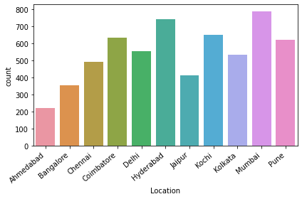

```python
location_plot = sns.countplot(data['Location'])
location_plot.set_xticklabels(location_plot.get_xticklabels(), rotation=40, ha="right") # tilt text to prevent overlapping
plt.tight_layout()
plt.show()
```

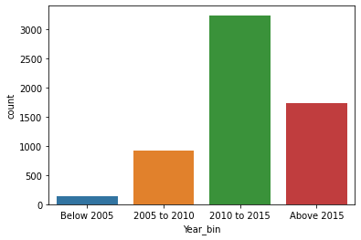

```python
sns.countplot(data['Year_bin'])
```

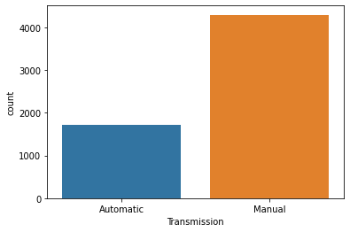

```python
sns.countplot(data['Transmission'])
```

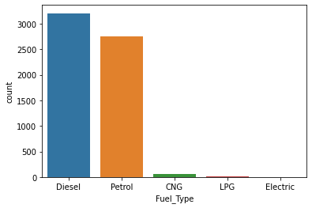

```python
sns.countplot(data['Fuel_Type'], order=pd.value_counts(data['Fuel_Type']).index)
```

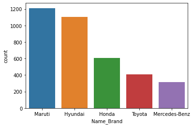

```python
sns.countplot(x='Name_Brand', data = data, order=pd.value_counts(data['Name_Brand']).iloc[:5].index) #showing top 5 brands
```

### Numerical:

```python
data.describe()
```

|  | Kilometers_Driven | Owner_Type | Mileage | Engine | Power | Seats | New_Price | Price |
| --- | --- | --- | --- | --- | --- | --- | --- | --- |
| count | 6.019000e+03 | 6019.000000 | 6019.000000 | 6019.000000 | 6019.000000 | 6019.000000 | 6019.000000 | 6019.000000 |
| mean | 5.873838e+04 | 1.202858 | 18.134966 | 1620.509221 | 112.883539 | 5.277621 | 13.231432 | 9.479468 |
| std | 9.126884e+04 | 0.456356 | 4.581528 | 599.635458 | 53.283701 | 0.803479 | 10.446181 | 11.187917 |
| min | 1.710000e+02 | 1.000000 | 0.000000 | 72.000000 | 34.200000 | 2.000000 | 3.910000 | 0.440000 |
| 25% | 3.400000e+04 | 1.000000 | 15.170000 | 1198.000000 | 78.000000 | 5.000000 | 11.670000 | 3.500000 |
| 50% | 5.300000e+04 | 1.000000 | 18.150000 | 1493.000000 | 97.700000 | 5.000000 | 11.670000 | 5.640000 |
| 75% | 7.300000e+04 | 1.000000 | 21.100000 | 1969.000000 | 138.030000 | 5.000000 | 11.670000 | 9.950000 |
| max | 6.500000e+06 | 4.000000 | 33.540000 | 5998.000000 | 560.000000 | 10.000000 | 230.000000 | 160.000000 |

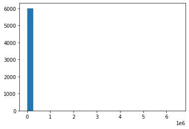

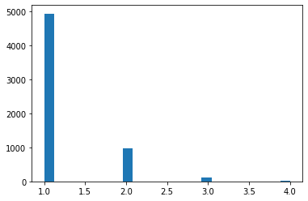

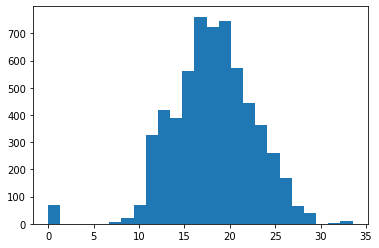

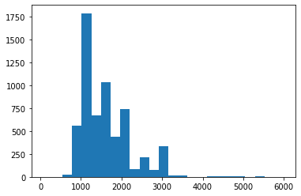

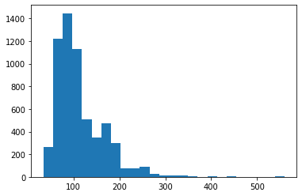

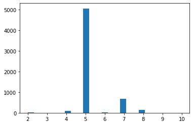

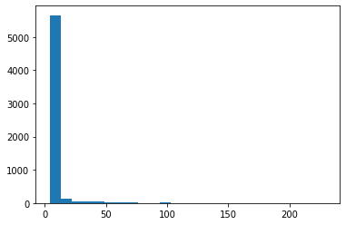

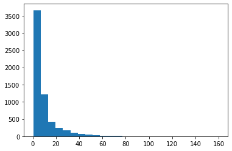

```python
plt.hist(data['Kilometers_Driven'], bins =25)
plt.show()
plt.hist(data['Owner_Type'], bins =25)
plt.show()
plt.hist(data['Mileage'], bins =25)
plt.show()
plt.hist(data['Engine'], bins =25)
plt.show()
plt.hist(data['Power'], bins =25)
plt.show()
plt.hist(data['Seats'], bins =25)
plt.show()
plt.hist(data['New_Price'], bins =25)
plt.show()
plt.hist(data['Price'], bins =25)
plt.show()
```

### Fix Skewness

```python
cols_to_log = ['Engine','Power','Mileage','Price']
for colname in cols_to_log:
    data[colname + '_log'] = np.log(data[colname] + 1)
data.drop(cols_to_log, axis=1, inplace=True)
```

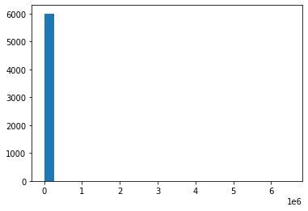

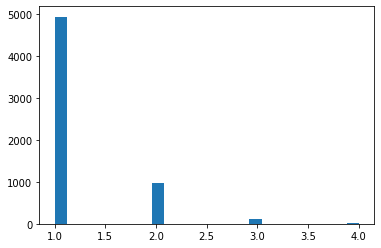

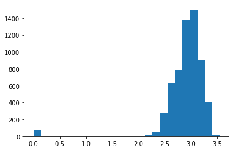

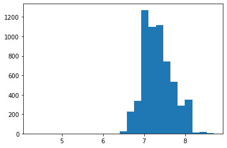

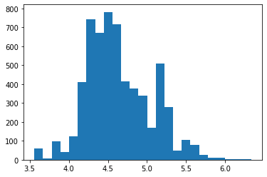

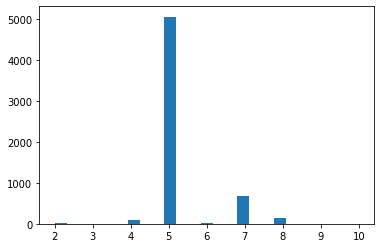

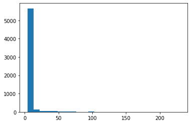

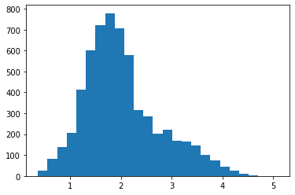

```python
plt.hist(data['Kilometers_Driven'], bins =25)
plt.show()
plt.hist(data['Owner_Type'], bins =25)
plt.show()
plt.hist(data['Mileage_log'], bins =25)
plt.show()
plt.hist(data['Engine_log'], bins =25)
plt.show()
plt.hist(data['Power_log'], bins =25)
plt.show()
plt.hist(data['Seats'], bins =25)
plt.show()
plt.hist(data['New_Price'], bins =25)
plt.show()
plt.hist(data['Price_log'], bins =25)
plt.show()
```

## EDA Multivariable analysis:

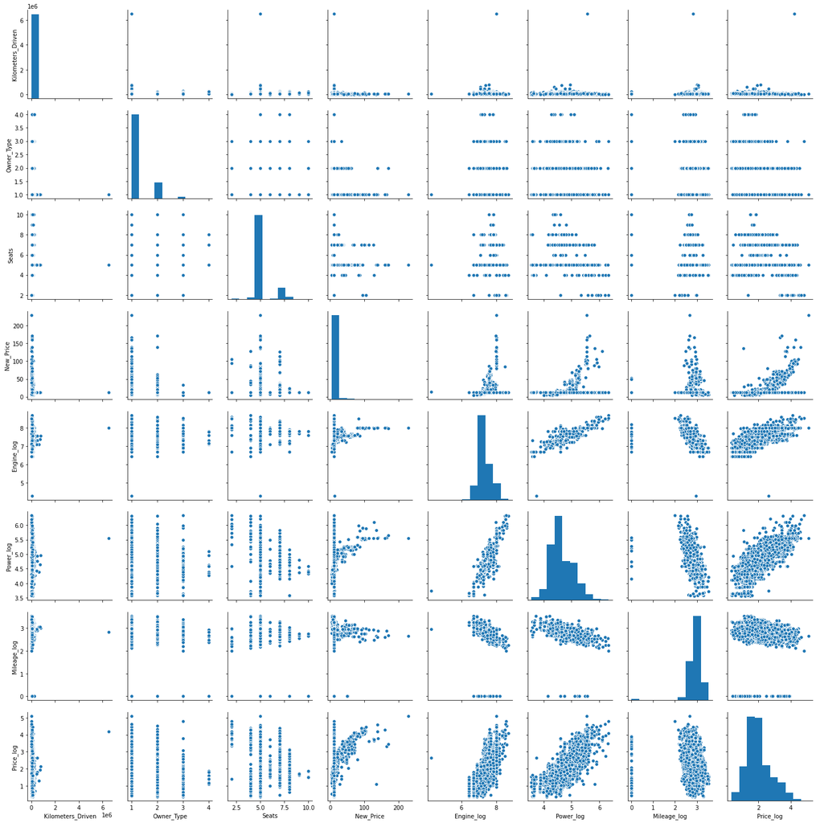

```python
sns.pairplot(data)
plt.show()
```

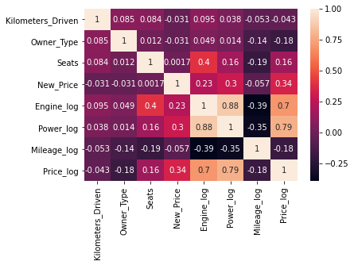

```python
sns.heatmap(data.corr(), annot=True)
```

## Linear Regression:

```python
# Create dummy variables
data = pd.get_dummies(data, columns=['Location',
'Year_bin',
'Transmission',
'Fuel_Type', 'Name_Brand'])

data.shape
```

```
(6019, 64)
```

```python
# data.info()
```

```python
# Separate dependent with independent
X = data.drop(['Price_log', 'Name_Model'], axis=1)
y = data[['Price_log']]
```

```python
X_train, X_test, y_train, y_test = train_test_split(X, y, test_size=0.30, random_state=1)
```

```python
reg_mod = LinearRegression()
reg_mod.fit(X_train, y_train)
```

```
LinearRegression(copy_X=True, fit_intercept=True, n_jobs=None, normalize=False)
```

```python
for idx, col_name in enumerate(X_train.columns):
    print("The coefficient for {} is {}".format(col_name, reg_mod.coef_[0][idx]))
```

```
The coefficient for Kilometers_Driven is -1.6839521546657056e-06
The coefficient for Owner_Type is -0.08345600922747907
The coefficient for Seats is 0.04466235682656017
The coefficient for New_Price is 0.0018873697564917302
The coefficient for Engine_log is 0.3231778414354298
The coefficient for Power_log is 0.6013135587079671
The coefficient for Mileage_log is 0.0024395170434623054
The coefficient for Location_Ahmedabad is -0.014921467883009631
The coefficient for Location_Bangalore is 0.13465863657721872
The coefficient for Location_Chennai is -0.007560843060089528
The coefficient for Location_Coimbatore is 0.1390603375344206
The coefficient for Location_Delhi is -0.07287827611699738
The coefficient for Location_Hyderabad is 0.09979790839031988
The coefficient for Location_Jaipur is -0.02128423453624971
The coefficient for Location_Kochi is 0.011843049726440291
The coefficient for Location_Kolkata is -0.19355216447351278
The coefficient for Location_Mumbai is -0.04794961915552907
The coefficient for Location_Pune is -0.027213327002908072
The coefficient for Year_bin_Below 2005 is -0.5154707830429484
The coefficient for Year_bin_2005 to 2010 is -0.2027798608517177
The coefficient for Year_bin_2010 to 2015 is 0.20443505006026777
The coefficient for Year_bin_Above 2015 is 0.5138155938345617
The coefficient for Transmission_Automatic is 0.05502586590576142
The coefficient for Transmission_Manual is -0.0550258659057804
The coefficient for Fuel_Type_CNG is -0.12401312097734302
The coefficient for Fuel_Type_Diesel is -0.019460639389973333
The coefficient for Fuel_Type_Electric is 0.5061173765223267
The coefficient for Fuel_Type_LPG is -0.18618727535472465
The coefficient for Fuel_Type_Petrol is -0.17645634080042893
The coefficient for Name_Brand_Ambassador is 0.20071970266696093
The coefficient for Name_Brand_Audi is 0.32640118255846445
The coefficient for Name_Brand_BMW is 0.2616671922004596
The coefficient for Name_Brand_Bentley is 0.8077671745800807
The coefficient for Name_Brand_Chevrolet is -0.5408500147897137
The coefficient for Name_Brand_Datsun is -0.5711953112073261
The coefficient for Name_Brand_Fiat is -0.48898068204999945
The coefficient for Name_Brand_Force is -0.1453307421536783
The coefficient for Name_Brand_Ford is -0.2911048870056053
The coefficient for Name_Brand_Hindustan is -6.661338147750939e-16
The coefficient for Name_Brand_Honda is -0.29660500231281073
The coefficient for Name_Brand_Hyundai is -0.2829231372024167
The coefficient for Name_Brand_ISUZU is -0.6852365162695306
The coefficient for Name_Brand_Isuzu is -6.938893903907228e-17
The coefficient for Name_Brand_Jaguar is 0.4316065470771223
The coefficient for Name_Brand_Jeep is -0.004832374552820984
The coefficient for Name_Brand_Lamborghini is 1.4989080610016465
The coefficient for Name_Brand_Land is 0.6353935580788607
The coefficient for Name_Brand_Mahindra is -0.4215021761614607
The coefficient for Name_Brand_Maruti is -0.23123645477668753
The coefficient for Name_Brand_Mercedes-Benz is 0.3223705086867986
The coefficient for Name_Brand_Mini is 0.6349195118318303
The coefficient for Name_Brand_Mitsubishi is -0.05625508867694809
The coefficient for Name_Brand_Nissan is -0.3158532224208649
The coefficient for Name_Brand_OpelCorsa is 1.1102230246251565e-16
The coefficient for Name_Brand_Porsche is 0.47783701121759864
The coefficient for Name_Brand_Renault is -0.2872131014892012
The coefficient for Name_Brand_Skoda is -0.26374724963435286
The coefficient for Name_Brand_Smart is 0.027993803345557067
The coefficient for Name_Brand_Tata is -0.5421382599429363
The coefficient for Name_Brand_Toyota is -0.062021658774411986
The coefficient for Name_Brand_Volkswagen is -0.3166080806754847
The coefficient for Name_Brand_Volvo is 0.17804970685092616
```

```python
interc = reg_mod.intercept_[0]
print(f"The intercept for our model is {interc}") #mean 18.941 median: 16.921 drop:1218572290 after scaling:-3.13
```

```
The intercept for our model is -3.1398640392136112
```

```python
reg_mod.score(X_train, y_train) #mean: 0.965 median: 0.965 drop: 0.984 after scaling:0.906
```

```
0.9063645900599933
```

```python
#out of sample score (R^2)

reg_mod.score(X_test, y_test) #mean: 0.782 median: 0.784 drop: -9024648661813 after scaling:0.789

#(Q for discussion: Would corrlation imputation work?)
```

```
0.789139042941318
```

# Final Conclusion:

It would be very benefitial to collect more accurate data in the price of the car in new condition, since it is expected to be highly correlated with the price of used car. Considering adding more stats of purchasing the used car from the original rider to have two different dependent variables. It is also very important to keep the buying and selling data disclosed to other business.

When purchasing the used car, it is still important to firmly check the conditions of the car. the features stated in the model don't count every details of the used car. (e.g accidents).